# Lab_2

```python
import numpy as np
import matplotlib
import matplotlib.pyplot as plt
import scipy
from scipy import stats
```

Suppose we are looking for gamma ray sources, and there is a background of cosmic rays providing a discrete noise term following a Poisson distribution. This background distribution can be modeled with the equation $f(k) = e^{-\mu}\frac{\mu^k}{k!}$, where $k$ is the number of events and $\mu$ is the shape parameter. If we measure a particular value $Y$ and the background has a distribution around $\mu=X$, we can use the integral of the probability distribution function from the value $Y$ to positive infinity to discover with what probability the background would give us a measurement $Y$. Below is a graph showing the background distribution as well as the measurement that is a candidate for being a possible signal as measured over the course of one day of data collection.

```python
plt.rcParams["figure.figsize"] = (15,10)
X = 6
Y = 8
```

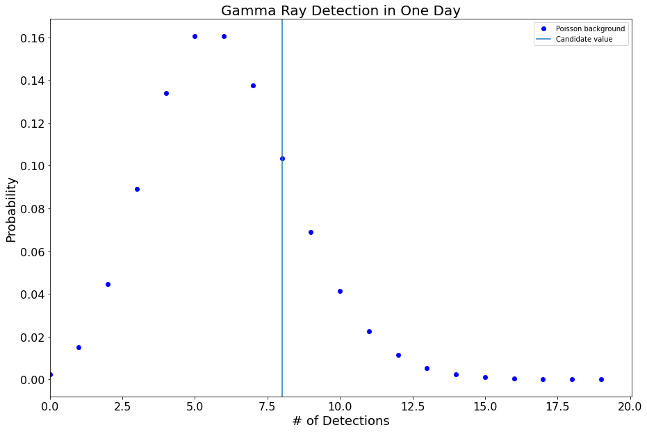

```python
fig, ax = plt.subplots(1, 1)
plt.tick_params(labelsize = 16)
plt.xlim([0,20.05])
x = np.arange(0,20)
avg = stats.poisson.pmf(x, X, loc=0)
sig = stats.poisson.pmf(x, Y, loc=0)
ax.set_xlabel('# of Detections', fontsize=18)
ax.set_ylabel('Probability', fontsize=18)
ax.plot(x, avg, 'bo', ms=6, label='Poisson background')
#ax.plot(x, sig, 'ro', ms=6, label='Poisson measurement')
plt.axvline(x=Y, ymin=0, ymax=1, label='Candidate value')
plt.title('Gamma Ray Detection in One Day', fontsize=20)
ax.legend()
plt.show()
```

As a check to make sure our calculations make sense and our probabilities sum to one, we can sum over the function. As shown below, the math works out and the sum is approximately one.

```python
print(np.sum(avg))
print(np.sum(sig))
```

```
0.9999948198310626
0.9997470605979063
```

In order to see the distribution which represents the sum of data collection over a number of days, we use the convolution of the previous day's data for each new consecutive day that data is collected. As seen below in the collection of graphs showing the background data collected over different numbers of days, more days of data collection cause the background distribution to have a larger mean and a wider distribution. Likewise, the candidate measurement increases proportional to the number of days in which the data is collected.

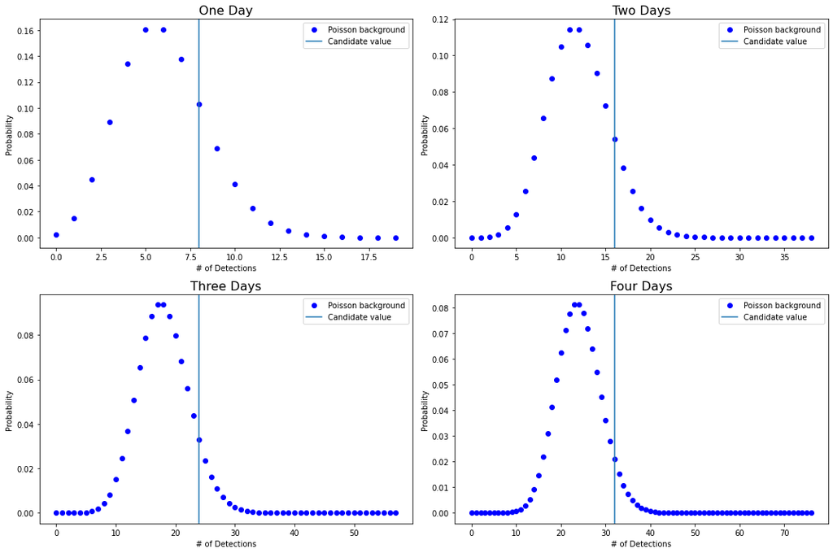

```python
avg_2 = np.convolve(avg, avg)
sig_2 = np.convolve(sig, sig)
avg_3 = np.convolve(avg_2, avg)
sig_3 = np.convolve(sig_2, sig)
avg_4 = np.convolve(avg_3, avg)
sig_4 = np.convolve(sig_3, sig)
x_2 = np.arange(0,39)
x_3 = np.arange(0,58)
x_4 = np.arange(0,77)

fig, axs = plt.subplots(2, 2)
axs[0, 0].plot(x, avg, 'bo', label='Poisson background')
#axs[0, 0].plot(x, sig, 'ro', label='Poisson measurement')
axs[0, 0].axvline(x=Y, ymin=0, ymax=1, label='Candidate value')
axs[0, 0].set_title('One Day', fontsize=16)
axs[0, 1].plot(x_2, avg_2, 'bo', label='Poisson background')
#axs[0, 1].plot(x_2, sig_2, 'ro', label='Poisson measurement')
axs[0, 1].axvline(x=2*Y, ymin=0, ymax=1, label='Candidate value')
axs[0, 1].set_title('Two Days', fontsize=16)
axs[1, 0].plot(x_3, avg_3, 'bo', label='Poisson background')
#axs[1, 0].plot(x_3, sig_3, 'ro', label='Poisson measurement')
axs[1, 0].axvline(x=3*Y, ymin=0, ymax=1, label='Candidate value')
axs[1, 0].set_title('Three Days', fontsize=16)
axs[1, 1].plot(x_4, avg_4, 'bo', label='Poisson background')
#axs[1, 1].plot(x_4, sig_4, 'ro', label='Poisson measurement')
axs[1, 1].axvline(x=4*Y, ymin=0, ymax=1, label='Candidate value')
axs[1, 1].set_title('Four Days', fontsize=16)
axs[0,0].legend()
axs[0,1].legend()
axs[1,0].legend()
axs[1,1].legend()

for ax in axs.flat:
    ax.set(xlabel='# of Detections', ylabel='Probability')

fig.tight_layout()
```

```python
avg_5 = np.convolve(avg_4, avg)
sig_5 = np.convolve(sig_4, sig)
```

```python
print(avg_5.size)
print(sig_5.size)
```

```
96
96
```

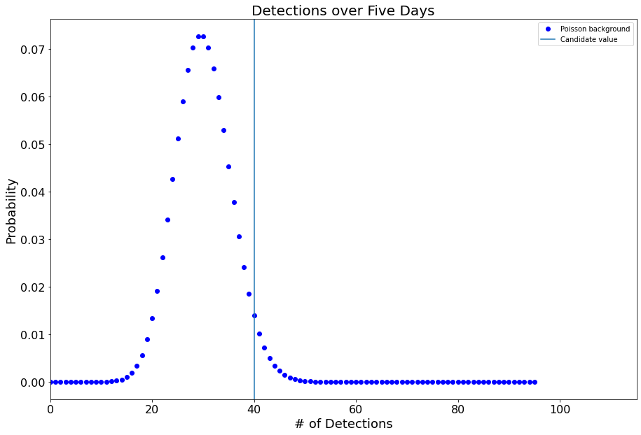

```python
fig, ax = plt.subplots(1, 1)
plt.tick_params(labelsize = 16)
plt.xlim([0,115.05])
x_5 = np.arange(0,96)
ax.plot(x_5, avg_5, 'bo', ms=6, label='Poisson background')
#ax.plot(x_5, sig_5, 'ro', ms=6, label='Poisson measurement')
ax.set_xlabel('# of Detections', fontsize=18)
ax.set_ylabel('Probability', fontsize=18)
plt.title('Detections over Five Days', fontsize=20)
plt.axvline(x=5*Y, ymin=0, ymax=1, label='Candidate value')
ax.legend()
plt.show()
```

As we can see, each of these show that though the days, the amount of data gathered, and the mean around which the data is distributed all increase, the result of each new day is still a Poisson distribution. This makes sense because we will necessarily always be dealing with a discrete number of events (or measurements) since the original background is a Poisson distribution of the number of gamma rays received. Adding discrete data sets will always return a discrete data set, and the distribution type will be maintained though the breadth of the distribution may change. In order to check that we are still getting proper probabilities from our distributions, we sum over the probability function; since we get values of approximately one, this shows we are on the right track.

```python
print(np.sum(avg_5))
print(np.sum(sig_5))
```

```
0.9999740994236536
0.9987359426111363
```

Averaging the data results over multiple days requires that the data for one day be normalized before being summed each day.

```python
avg = avg/np.sum(avg)
sig = sig/np.sum(sig)
comb_1 = avg
comb_2 = sig
comb_3 = avg
comb_4 = sig
comb_5 = avg
comb_6 = sig
comb_7 = avg
comb_8 = sig

for i in range (0,2):
    comb_1 = np.convolve(comb_1,avg)
    comb_2 = np.convolve(comb_2,sig)

for i in range (0,4):
    comb_3 = np.convolve(comb_3,avg)
    comb_4 = np.convolve(comb_4,sig)

for i in range (0,6):
    comb_5 = np.convolve(comb_5,avg)
    comb_6 = np.convolve(comb_6,sig)

for i in range (0,8):
    comb_7 = np.convolve(comb_7,avg)
    comb_8 = np.convolve(comb_8,sig)

x_6 = np.arange(0,20,0.34482758621)
x_7 = np.arange(0,20,0.20833333334)
x_8 = np.arange(0,20,0.149253731345)
x_9 = np.arange(0,20,0.1162790698)
```

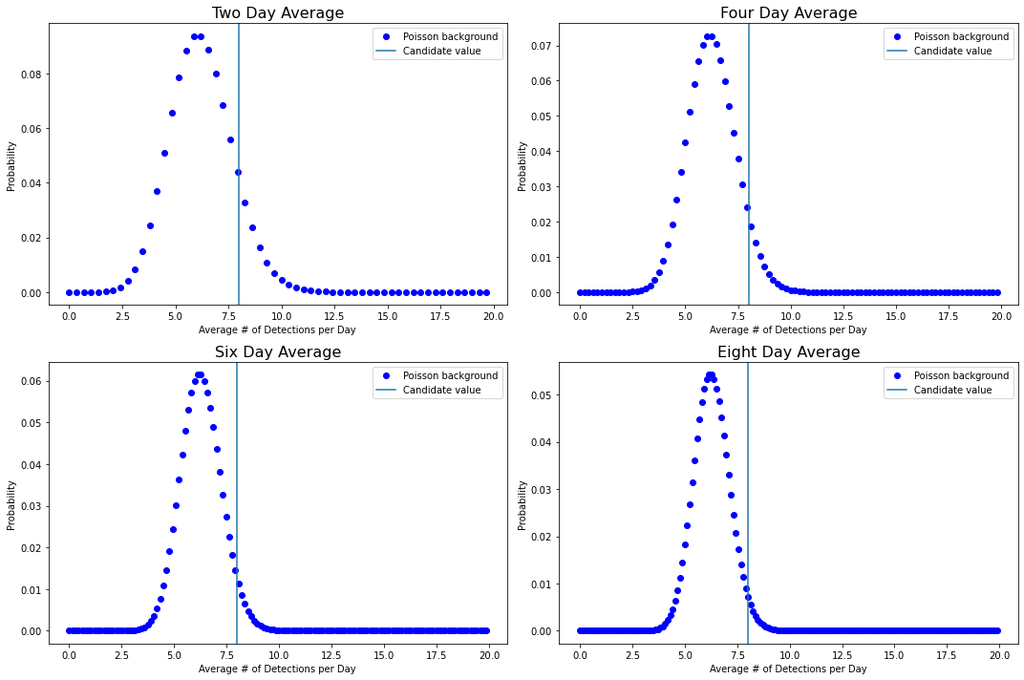

```python
fig, axs = plt.subplots(2, 2)
axs[0, 0].plot(x_6, comb_1, 'bo', label='Poisson background')
#axs[0, 0].plot(x_6, comb_2, 'ro', label='Poisson measurement')
axs[0, 0].axvline(x=Y, ymin=0, ymax=1, label='Candidate value')
axs[0, 0].set_title('Two Day Average', fontsize=16)
axs[0, 1].plot(x_7, comb_3, 'bo', label='Poisson background')
#axs[0, 1].plot(x_7, comb_4, 'ro', label='Poisson measurement')
axs[0, 1].axvline(x=Y, ymin=0, ymax=1, label='Candidate value')
axs[0, 1].set_title('Four Day Average', fontsize=16)
axs[1, 0].plot(x_8, comb_5, 'bo', label='Poisson background')
#axs[1, 0].plot(x_8, comb_6, 'ro', label='Poisson measurement')
axs[1, 0].axvline(x=Y, ymin=0, ymax=1, label='Candidate value')
axs[1, 0].set_title('Six Day Average', fontsize=16)
axs[1, 1].plot(x_9, comb_7, 'bo', label='Poisson background')
#axs[1, 1].plot(x_9, comb_8, 'ro', label='Poisson measurement')
axs[1, 1].axvline(x=Y, ymin=0, ymax=1, label='Candidate value')
axs[1, 1].set_title('Eight Day Average', fontsize=16)
axs[0,0].legend()
axs[0,1].legend()
axs[1,0].legend()
axs[1,1].legend()

for ax in axs.flat:
    ax.set(xlabel='Average # of Detections per Day', ylabel='Probability')

fig.tight_layout()
```

As we can see from the graphs above, averaging the data does not change the mean of the distribution, but it does narrow the breadth of the distribution such that those values closer to the mean increase in probability and those further away decrease in probability. Therefore, as we average more and more days' data together, the probability that our candidate measurement was produced by the background decreases.

This is in contrast to the widening that occurs as we sum over more days. This makes sense, because with a greater number of days there are more quantities available due to the summing of data sets, which broadens the distribution. Likewise, with a greater number of sums available, the likelihood that values closer to the background's mean show up in any of those sums is increased. Therefore, the average distribution is strengthened closer to the mean, and the probability distribution is narrowed as a result.

As regards the Central Limit Theorem, averaging the data sets over more days results in a greater number of events occuring over the same domain, and also results in events numbers becoming represented by decimals because the discrete measurements have been averaged. The more times we average, the more data points we will have in our distribution, and eventually there are enough points that the distribution can be appropriately modeled using a continuous normal distribution.

```python
comb_9 = avg
comb_10 = sig
for i in range (0,10):
    comb_9 = np.convolve(comb_9,avg)
    comb_10 = np.convolve(comb_10,sig)
```

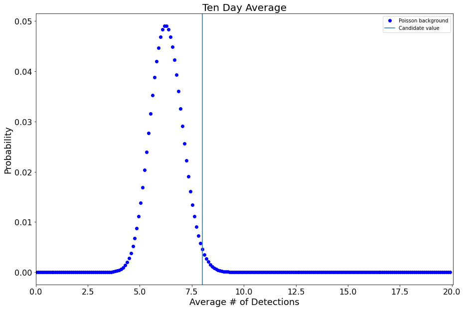

```python
fig, ax = plt.subplots(1, 1)
plt.tick_params(labelsize = 16)
plt.xlim([0,20.05])
x_10 = np.arange(0,20,0.09524)
ax.plot(x_10, comb_9, 'bo', ms=6, label='Poisson background')
#ax.plot(x_10, comb_10, 'ro', ms=6, label='Poisson measurement')
ax.set_xlabel('Average # of Detections', fontsize=18)
ax.set_ylabel('Probability', fontsize=18)
plt.axvline(x=Y, ymin=0, ymax=1, label='Candidate value')
ax.legend()
plt.title('Ten Day Average', fontsize=20)
plt.show()
```

Above shows the averaging over ten days.

```python
print(np.sum(comb_9))
print(np.sum(comb_10))
```

```
1.0000000000000007
0.9999999999999989
```

```python
N = 25
det = Y*N
print(det)
```

```
200
```

```python
sum_3 = stats.poisson.pmf(x, X, loc=0)
sum_4 = stats.poisson.pmf(x, Y, loc=0)
sum_5 = sum_3
sum_6 = sum_4

for k in range (0,N):
    sum_5 = np.convolve(sum_5, sum_3)
    sum_6 = np.convolve(sum_6, sum_4)

x_9 = np.arange(0,sum_5.size)
print(sum_5.size)
```

```
495
```

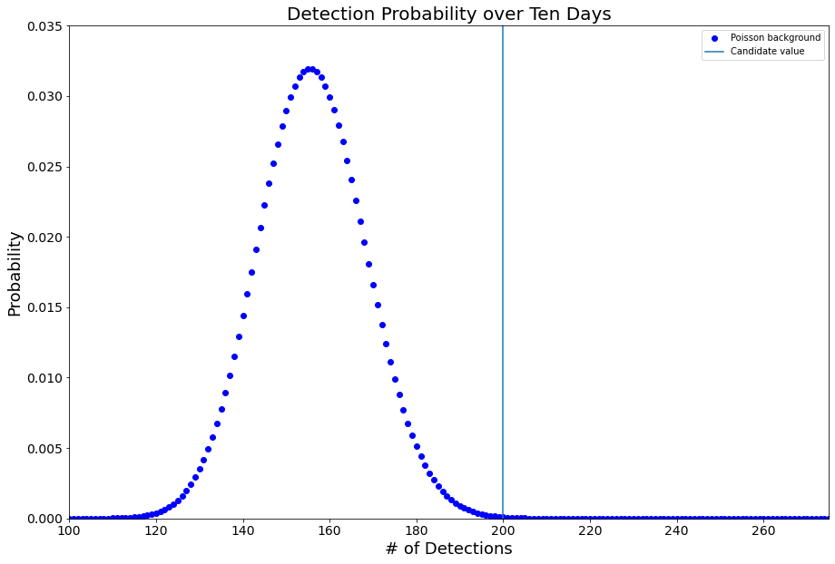

```python
fig, ax = plt.subplots(1, 1)
plt.tick_params(labelsize = 14)
plt.xlim([100,275])
plt.ylim([0,0.035])
ax.plot(x_9, sum_5, 'bo', ms=6, label='Poisson background')
ax.set_xlabel('# of Detections', fontsize=18)
ax.set_ylabel('Probability', fontsize=18)
plt.title('Detection Probability over Ten Days', fontsize=20)
plt.axvline(x=det, label='Candidate value')
ax.legend()
plt.show()
```

```python
print(np.max(sum_5))
```

```
0.031921841184472416
```

```python
print(np.where(sum_5 == 0.031921841184472416))
```

```
(array([155]),)
```

```python
P = stats.poisson.sf(det, x_9[155], loc=0)
print(P)
```

```
0.00022614546218686855
```

```python
sigma = stats.norm.isf(P, loc=0, scale=1)
print(sigma)
```

```
3.507527899458318
```

The calculations above show that a measurement equal to or larger than our candidate when measured over twenty-five consecutive days has a probability of approximately 0.02 in 100 of being produced by the background distribution, giving a sigma of approximately 3.51. This is not a sigma large enough to indicate statistical significance (such a sigma must be 5.0 or higher), but it is an indication that taking and summing more days' worth of data could possibly strengthen its significance.

When looking at the averaging of a skewed distribution, such as a Rayleigh distribution, we don't just see differences in the breadth of the distribution or the probabilities for values close to the mean. We also see a change in the overall shape of the distribution.

Below is a graph of a Rayleigh distribution as described by the equation $f(x) = xe^{-\frac{x^2}{2}}$.

```
[]
```

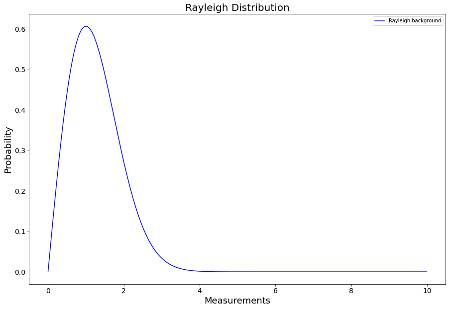

```python
from scipy.stats import rayleigh
import matplotlib.pyplot as plt

x_10 = np.arange(0,10,0.01)
fig, ax = plt.subplots(1, 1)
plt.tick_params(labelsize = 14)
d = stats.rayleigh.pdf(x_10, loc=0, scale=1)
ax.plot(x_10, d, 'b', label='Rayleigh background')
ax.set_xlabel('Measurements', fontsize=18)
ax.set_ylabel('Probability', fontsize=18)
ax.legend()
plt.title('Rayleigh Distribution', fontsize=20)
plt.plot()
```

As we average over increased numbers of days, the resultant Rayleigh distribution looks less and less skewed, and more and more closely resembles a Gaussian distribution. This occurs as the right-hand side of the distribution becomes more steep with a less pronouced tail, and as the left-hand side becomes less steep and more rounded. This is due to the decreased probability of those values further from the value corresponding to the peak probability, and the increased probability for those values which are closer. The x-values corresponding to the peak probability shift slightly by increasing with increased averagings of the dataset.

```python
d = d/np.sum(d)
comb_11 = d
comb_12 = d
comb_13 = d
comb_14 = d
comb_15 = d

for i in range (0,4):
    comb_11 = np.convolve(comb_11,d)

for i in range (0,8):
    comb_12 = np.convolve(comb_12,d)

for i in range (0,20):
    comb_13 = np.convolve(comb_13,d)

for i in range (0,100):
    comb_14 = np.convolve(comb_14,d)

x_11 = np.linspace(0,10,4996)
x_12 = np.linspace(0,10,8992)
x_13 = np.linspace(0,10,20980)
x_14 = np.linspace(0,10,100900)
```

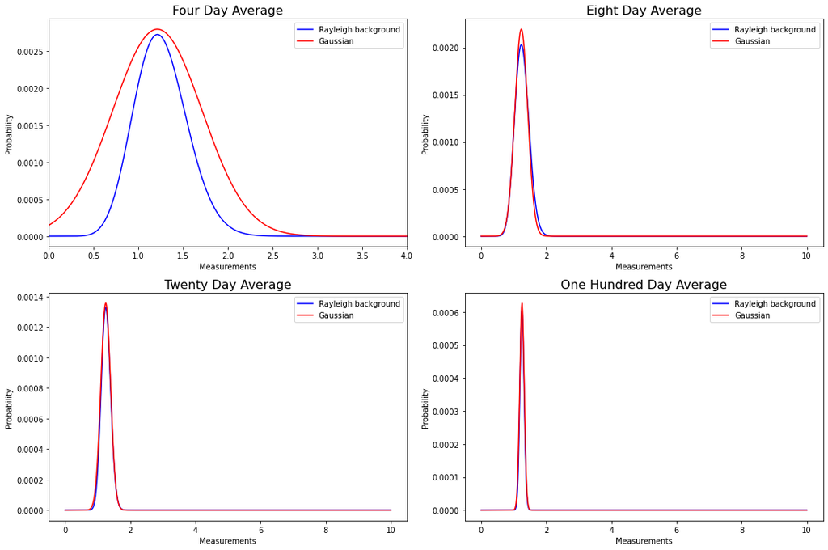

```python
fig, axs = plt.subplots(2, 2)
axs[0, 0].plot(x_11, comb_11, 'b', label='Rayleigh background')
axs[0, 0].plot(x_11, 0.0035*stats.norm.pdf(x_11,loc=1.2112112112112112,scale=0.5), 'r-', label='Gaussian')
axs[0, 0].set_title('Four Day Average', fontsize=16)
axs[0, 0].set_xlim([0,4])
axs[0, 1].plot(x_12, comb_12, 'b', label='Rayleigh background')
axs[0, 1].plot(x_12, 0.0011*stats.norm.pdf(x_12,loc=1.2312312312312312,scale=0.2), 'r-', label='Gaussian')
axs[0, 1].set_title('Eight Day Average', fontsize=16)
axs[1, 0].plot(x_13, comb_13, 'b', label='Rayleigh background')
axs[1, 0].plot(x_13, 0.00051*stats.norm.pdf(x_13,loc=1.2445779112445778,scale=0.15), 'r-', label='Gaussian')
axs[1, 0].set_title('Twenty Day Average', fontsize=16)
axs[1, 1].plot(x_14, comb_14, 'b', label='Rayleigh background')
axs[1, 1].plot(x_14, 0.00011*stats.norm.pdf(x_14,loc=1.2525396683812526,scale=0.07), 'r-', label='Gaussian')
axs[1, 1].set_title('One Hundred Day Average', fontsize=16)
axs[0,0].legend()
axs[0,1].legend()
axs[1,0].legend()
axs[1,1].legend()

for ax in axs.flat:
    ax.set(xlabel='Measurements', ylabel='Probability')

fig.tight_layout()
```

As shown above, by the time we get to approximately twenty averages, the distribution looks very close to a Gaussian of a similar size. By one hundred averages, it is hard to see a difference in the shapes of the two distributions on the graph.

Below are some calculations used to formulate Gaussians of similar size and position for comparison with the averaged Rayleigh distributions.

```python
print(np.max(d))
```

```
0.00606535714202191
```

```python
print(np.where(d == 0.00606535714202191))
```

```
(array([100]),)
```

```python
print(x_10[100])
```

```
1.0
```

```python
print(np.max(comb_11))
print(np.max(comb_12))
print(np.max(comb_13))
print(np.max(comb_14))
```

```
0.0027217586506756847
0.002029230288660148
0.0013286766092719961
0.0006059146048046043
```

```python
print(np.where(comb_11 == 0.0027217586506756847))
print(np.where(comb_12 == 0.002029230288660148))
print(np.where(comb_13 == 0.0013286766092719961))
print(np.where(comb_14 == 0.0006059146048046043))
```

```
(array([605]),)
(array([1107]),)
(array([2611]),)
(array([12638]),)
```

```python
print(x_11[605])
print(x_12[1107])
print(x_13[2611])
print(x_14[12638])
```

```
1.2112112112112112
1.2312312312312312
1.2445779112445778
1.2525396683812526
```

In order to see how close the averages and the modeled Gaussian distributions are as far as the probability values go, we can calculate the difference between the two. If we wanted to be even more exact, we could use also use fitting functions, but the results below show that our approximations have given a pretty fair similarity, depending on to what degree we need precision. The difference between the Gaussian and the averaged Rayleigh distributions for the twenty day average is approximately twice that of the one-hundred day average, and both are on the order of $10^{-5}$.

```python
print('Twenty day difference:', np.max(np.abs(comb_13 - 0.00051*stats.norm.pdf(x_13,loc=1.2445779112445778,scale=0.15))))
print('One hundred day difference:', np.max(np.abs(comb_14 - 0.00011*stats.norm.pdf(x_14,loc=1.2525396683812526,scale=0.07))))
```

```
Twenty day difference: 9.110905093016593e-05
One hundred day difference: 4.6711124972136976e-05
```

Suppose we have a zero-mean Gaussian of a given constant width $X1$ as the thermal background noise as measured by an optical CCD telescope. If we were to measure a signal of strength $Y1$, we can use the probability of its production by the Gaussian thermal background to calculate its statistical significance. Below is a graph of a random Gaussian distribution reprsenting the thermal background, the general Gaussian probability function that describes it, and the value of the candidate signal we have measured.

```python
X1 = 3.5
Y1 = 4.67
bg1 = stats.norm.rvs(loc=0,scale=X1/2.355,size=10000)
```

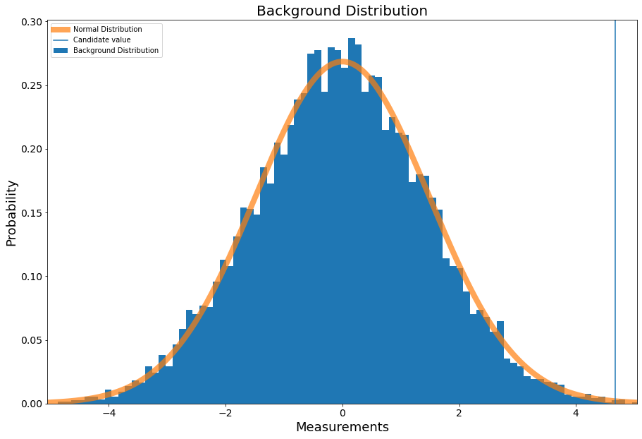

```python
fig, ax = plt.subplots(1, 1)
ax.hist(bg1, 100, density=True, label='Background Distribution')
plt.tick_params(labelsize = 14)
plt.xlim([-5.05,5.05])
x = np.linspace(-5.0, 5.0, 10000)
ax.plot(x, stats.norm.pdf(x, loc = 0, scale = X1/2.355), linewidth = 8, alpha = 0.7, label='Normal Distribution')
ax.set_xlabel('Measurements', fontsize=18)
ax.set_ylabel('Probability', fontsize=18)
plt.axvline(x=Y1, label='Candidate value')
ax.legend()
plt.title('Background Distribution', fontsize=20)
plt.show()
```

```python
P1 = stats.norm.sf(Y1, loc=0, scale=X1/2.355)
print(P1)
```

```
0.0008382945432838987
```

```python
sigma1 = stats.norm.isf(P1, loc=0, scale=1)
print(sigma1)
```

```
3.142242857142857
```

As shown above, the candidate value measured has a probability of approximately 8 in 10,000. Though this seems like it is quite a small probability, it still is not statistically significant, as it results in a sigma value of approximately 3.14.

If instead we are looking for a signal across 10,000 pixels, we should not use a Gaussian distribution. Instead, as we will be measuring the amount of signal per pixel, we will have a discrete dataset and thus need to use a Poisson distribution.

```python
x2 = np.arange(0,10000)
```

```python
bg2 = stats.poisson.pmf(x2, X1,loc=0)
```

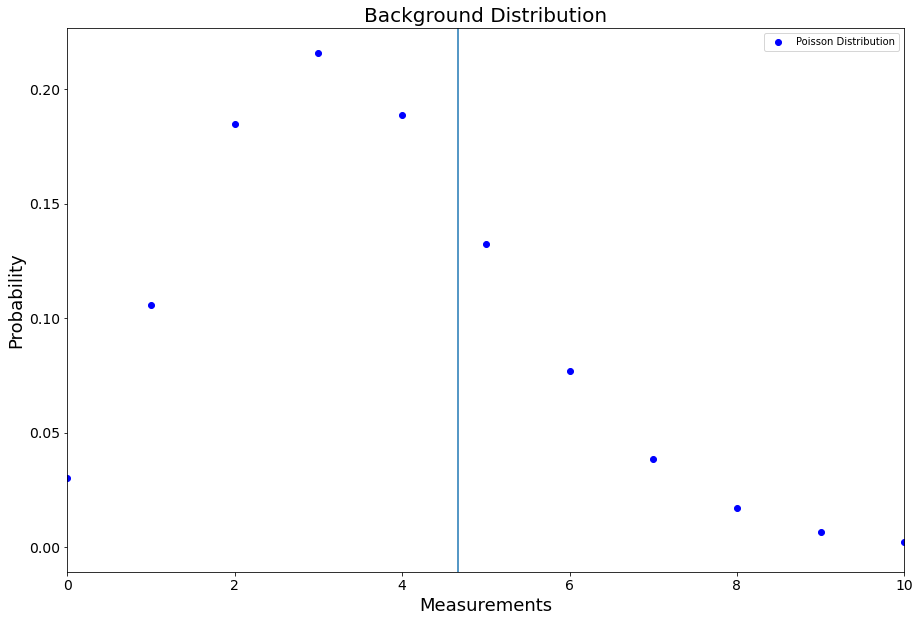

```python
fig, ax = plt.subplots(1, 1)
plt.tick_params(labelsize = 14)
plt.xlim([0,10])
x = np.linspace(0, 10000, 10000)
#ax.plot(x, stats.poisson.pmf(x, X1, loc=0), linewidth = 8, alpha = 0.7, label='Poisson Distribution')
ax.plot(x, bg2, 'bo', label='Poisson Distribution')
ax.set_xlabel('Measurements', fontsize=18)
ax.set_ylabel('Probability', fontsize=18)
plt.axvline(x=Y1)
ax.legend()
plt.title('Background Distribution', fontsize=20)
plt.show()
```

The graph above shows that changing the distribution to discrete one of 10,000 possibilities changes the statistical proximity of our candidate measurement to the mean.

```python
P2 = stats.poisson.sf(Y1, X1, loc=0)
print(P2)
```

```
0.2745550466903957
```

```python
sigma2 = stats.norm.isf(P2, loc=0, scale=1)
print(sigma2)
```

```
0.5990941637053137
```

The calculations above show that the probability of getting a measurement like ours with the given distribution is about 30 in 100, so not very rare at all. Likewise, the sigma value of approximately 0.6 shows that this measurement is well within what we would expect to see from the thermal background and not in the least statistically significant.

If we did manage to measure a 5 sigma signal with respect to the Gaussian background and with respect to the Poisson background, they would not be of the same value for each (which is to be expected, based on the difference in significance of our candidate measurement between the two). In order to calculate what we could expect to be a statistically significant measurement, we can work backwards from the value 5 sigma, find the probability at which it occurs in a normal Gaussian distribution, and use that probability to find the value which corresponds to that probability in the other two distributions.

```python
P3 = stats.norm.sf(5, loc=0, scale=1)
signal_1 = stats.norm.isf(P3, loc=0, scale=X1/2.355)
print(signal_1)
```

```
7.430997876857751
```

The calculations above show that a measurement of approximately 7.4 at least is required in order to have statistical significance with respect to the known Gaussian background ot width $X1$. This means we need to make a measurement of at least 7.4 in order to be able to say that the probability that the value measured is produced by the thermal noise background is low enough that we can say it is an actual signal.

In order to find a 5 sigma measurement value for the Poisson distribution, we use the same process with the distribution-appropriate functions.

```python
signal_2 = stats.poisson.isf(P3, X1, loc=0)
print(signal_2)
```

```
16.0
```

```python
signal_2/signal_1
```

```
2.1531428571428566
```

Taking the ratio of the measurement necessary for statistical significance for the Poisson distribution and that for the Gaussian shows that the value necessary for the Poisson distribution is over twice that necessary for the Gaussian.